# HW 21

Harsha

2024-04-01

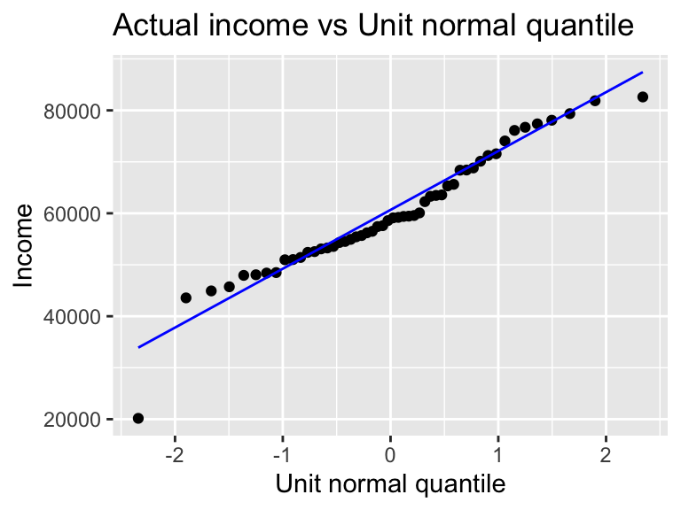

```r
library(dplyr)
library(ggplot2)
library(tukeyedar)

options(scipen = 99)
#load data
dat <- read.csv("census_income.csv")

#extract income
income  <- dat %>%
  arrange(income) %>%
  pull(income)


# Comparing income to a (unit) normal qq plot
ggplot(dat, aes(sample=income)) + stat_qq(distribution=qnorm) +
  stat_qq_line( col = "blue") +
  xlab("Unit normal quantile") + ylab("Income") +
  ggtitle("Actual income vs Unit normal quantile")
```

When comparing each state’s income to a normal distribution, we focus where the points follow the fitted line at the core of the dataset (i.e. between -1 and 1 standard deviations). In our case, our income data is approximately normal if most of our income points between -1 and 1 standard deviations fall on the blue line of what the income would be if they followed a normal distribution. We can see that between 50K and 70K, which is above and below a standard deviation from the mean of 0 in a standard normal distribution, most of the income points are relatively close to the line of what the points would be in a normal distribution. It should be noted that most of these income points seem to be a little less than what they would be in a normal population. We can examine further if this is a concern by simulating random normal income values and comparing that to our actual income values.

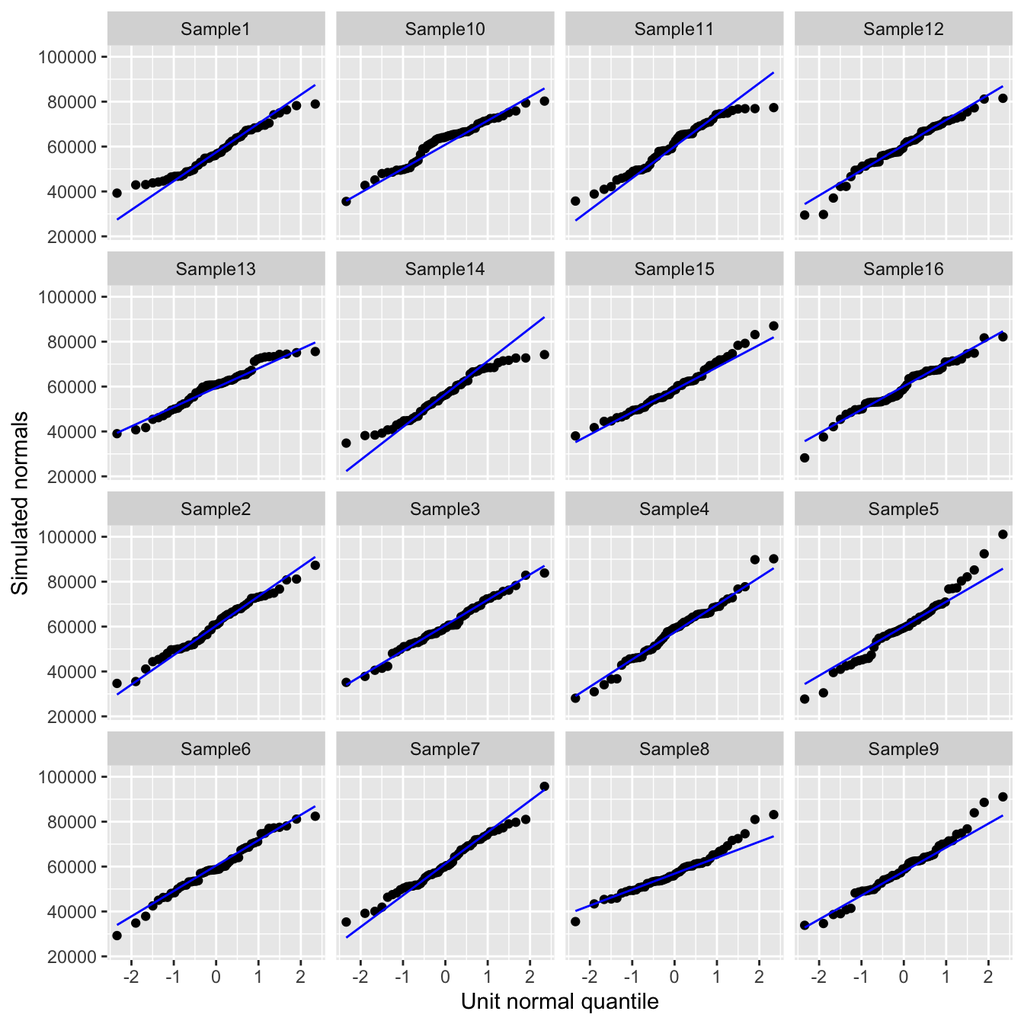

```r
# Simulate values from a normal distribution
sim <- data.frame(sample = paste0("Sample",1:16),
                  value  = round(rnorm(length(income)*16,
                                       mean = mean(income), sd = sd(income))))

# Generate q-q plots of the simulated values
ggplot(sim, aes(sample = value)) + stat_qq(distribution = qnorm) +
  stat_qq_line(line.p = c(0.25, 0.75), col = "blue") +
  xlab("Unit normal quantile") + ylab("Simulated normals") +
  facet_wrap(~ sample, nrow = 4)
```